# IODS course project

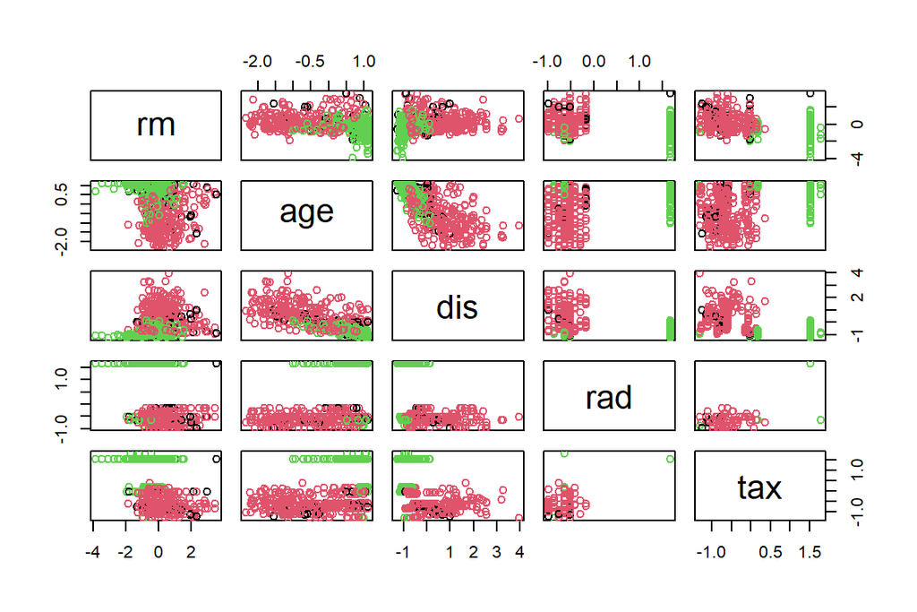

```r
pairs(Boston[,6:10], col = km3$cluster)
```

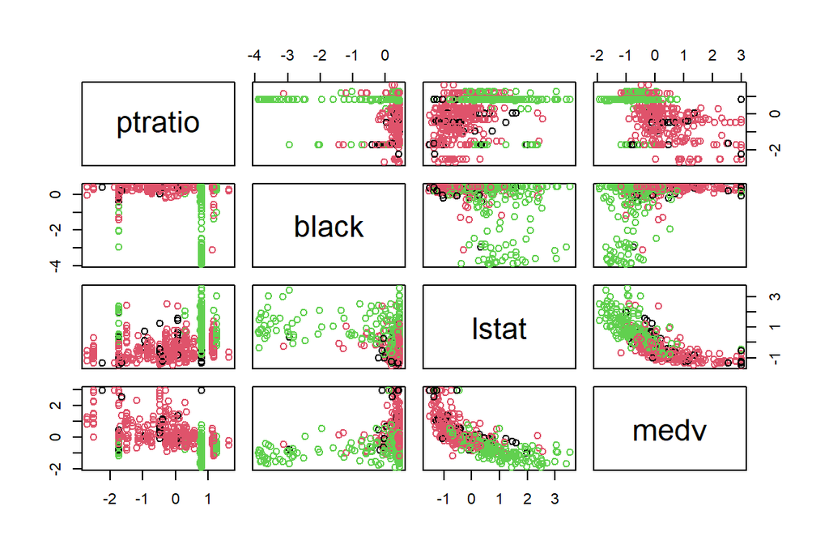

```r
pairs(Boston[,11:14], col = km3$cluster)
```

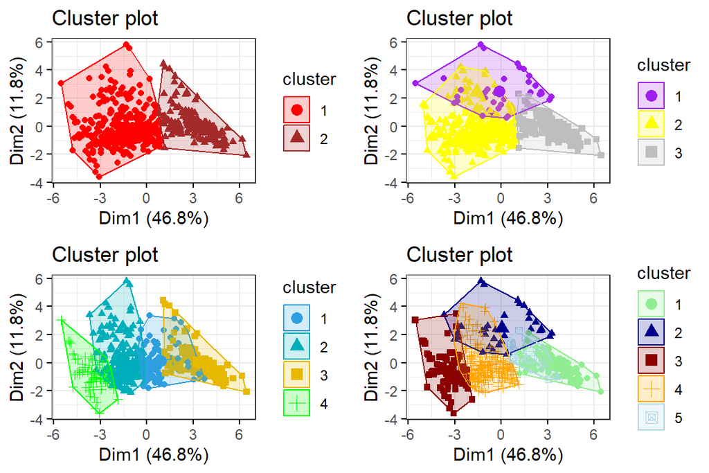

```r
# a more advanced plot
p_2 <- fviz_cluster(km2, data = Boston,
             palette = c("red", "brown"),
             geom = "point",
             ellipse.type = "convex",
             ggtheme = theme_bw())
p_3 <- fviz_cluster(km3, data = Boston,
             palette = c('purple', 'yellow', 'grey'),
             geom = "point",
             ellipse.type = "convex",
             ggtheme = theme_bw())
p_4 <- fviz_cluster(km4, data = Boston,
             palette = c("#2E9FDF", "#00AFBB", "#E7B800", 'green'),
             geom = "point",
             ellipse.type = "convex",
             ggtheme = theme_bw())
p_5 <- fviz_cluster(km5, data = Boston,
             palette = c("lightgreen", "darkblue", "darkred", 'orange', 'lightblue'),
             geom = "point",
             ellipse.type = "convex",
             ggtheme = theme_bw())
grid.arrange(grobs = list(p_2,p_3, p_4, p_5), nrow = 2)
```

With the k-means method you have to decide on the number of classes before running the algorithm. Therefor I used the elbow method - it is recommended to set the classes where the total within sum of sqaures does not decrease that much anymore. This point normally is called ‘elbow’. In this example there is not really an elbow - but maybe at 2, 3 or 4 (5) classes. Firstly, I tried 4, but after plotting 3 looked much better, so I chose this. To be sure I also plotted 2 and 5. To interpret the result: This is very hard for me, but I have a try: The output takes k-means results and the original data as arguments. It shows that somehow the 3 classes that have been build up are distinct even though there is overlap with group 1! Especially, between class 1 and 2 the boarder seems to be a bit random. The plot with 2 clusters much better - there is no overlap at all! The plots of 4 and 5 groups look a bit messy. All in all, I think it is reasonable to stay with 2 categories that have been built up with the k-means approach. NB: Somehow I had troubles with the plot of the 3 categories - the groups were built up slightly different each time I run the plot. Do you have an idea what causes this issues and how to solve this (statistically or in coding)?